# House Price Prediction

Subhasis Sur MD2223

2022-11-06

## Introduction

- House is one of the most necessities in the human life.
- A Good house is required for a good living.
- For a Good House ,Cost of it is very important.

## Objective

- To Bulid a model for Predicting House Price.
- Find relationships with some other things.

## Data structure

```
## 'data.frame':    21613 obs. of  21 variables:
##  $ id           : num  7.13e+09 6.41e+09 5.63e+09 2.49e+09 1.95e+09 ...
##  $ date         : chr  "20141013T000000" "20141209T000000" "20150225T000000" "20141209T000000" ...
##  $ price        : num  221900 538000 180000 604000 510000 ...
##  $ bedrooms     : int  3 3 2 4 3 4 3 3 3 3 ...
##  $ bathrooms    : num  1 2.25 1 3 2 4.5 2.25 1.5 1 2.5 ...
##  $ sqft_living  : int  1180 2570 770 1960 1680 5420 1715 1060 1780 1890 ...
##  $ sqft_lot     : int  5650 7242 10000 5000 8080 101930 6819 9711 7470 6560 ...
##  $ floors       : num  1 2 1 1 1 1 2 1 1 2 ...
##  $ waterfront   : int  0 0 0 0 0 0 0 0 0 0 ...
##  $ view         : int  0 0 0 0 0 0 0 0 0 0 ...
##  $ condition    : int  3 3 3 5 3 3 3 3 3 3 ...
##  $ grade        : int  7 7 6 7 8 11 7 7 7 7 ...
##  $ sqft_above   : int  1180 2170 770 1050 1680 3890 1715 1060 1050 1890 ...
##  $ sqft_basement: int  0 400 0 910 0 1530 0 0 730 0 ...
##  $ yr_built     : int  1955 1951 1933 1965 1987 2001 1995 1963 1960 2003 ...
##  $ yr_renovated : int  0 1991 0 0 0 0 0 0 0 0 ...
##  $ zipcode      : int  98178 98125 98028 98136 98074 98053 98003 98198 98146 98038 ...
##  $ lat          : num  47.5 47.7 47.7 47.5 47.6 ...
##  $ long         : num  -122 -122 -122 -122 -122 ...
##  $ sqft_living15: int  1340 1690 2720 1360 1800 4760 2238 1650 1780 2390 ...
##  $ sqft_lot15   : int  5650 7639 8062 5000 7503 101930 6819 9711 8113 7570 ...
```

## Data Cleaning and Modification

- Remove **id, lat ,long** coloumns
- Extract only first 4 digits of **zipcode**
- Convert **yr_renovated** to **renovated**
- Convert **renovated , zipcode ,grade ,condition , waterfront ,view , date** into categorical variables.
- Here, sqft living = sqft above + sqft basement
- Remove sqft living coloumn

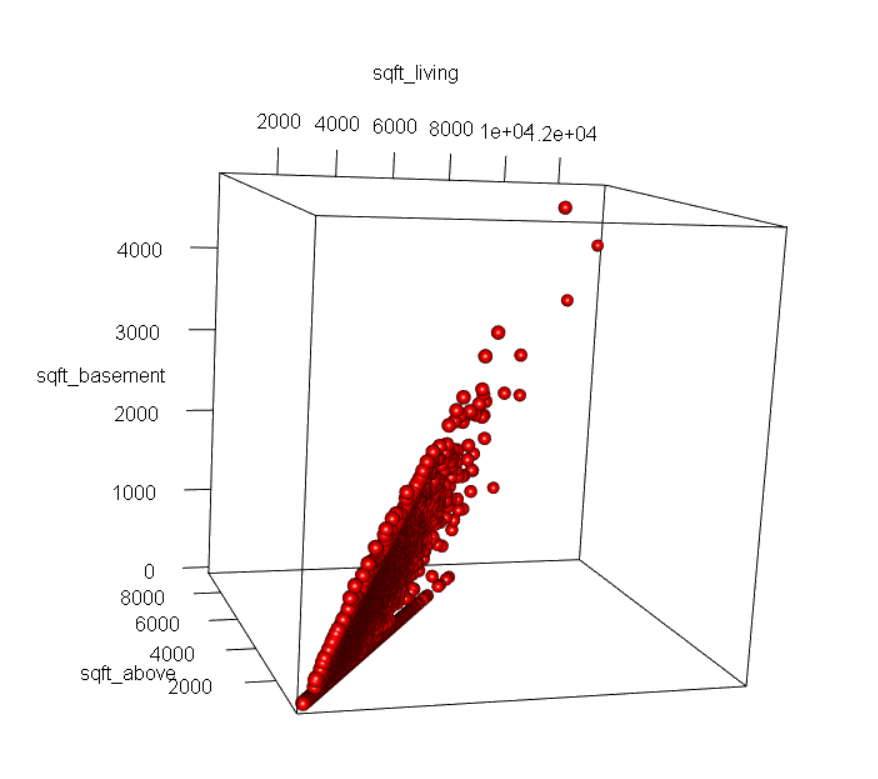

## Data structure after Modification

```r
str(house)
```

```
## 'data.frame':    21613 obs. of  17 variables:
##  $ date         : Factor w/ 2 levels "2014","2015": 1 1 2 1 2 1 1 2 2 2 ...
##  $ price        : num  221900 538000 180000 604000 510000 ...
##  $ bedrooms     : int  3 3 2 4 3 4 3 3 3 3 ...
##  $ bathrooms    : num  1 2 1 3 2 4 2 2 1 2 ...
##  $ sqft_lot     : int  5650 7242 10000 5000 8080 101930 6819 9711 7470 6560 ...
##  $ floors       : num  1 2 1 1 1 1 2 1 1 2 ...
##  $ waterfront   : Factor w/ 2 levels "0","1": 1 1 1 1 1 1 1 1 1 1 ...
##  $ view         : Factor w/ 5 levels "0","1","2","3",..: 1 1 1 1 1 1 1 1 1 1 ...
##  $ condition    : Factor w/ 5 levels "1","2","3","4",..: 3 3 3 5 3 3 3 3 3 3 ...
##  $ grade        : Factor w/ 12 levels "1","3","4","5",..: 6 6 5 6 7 10 6 6 6 6 ...
##  $ sqft_above   : int  1180 2170 770 1050 1680 3890 1715 1060 1050 1890 ...
##  $ sqft_basement: int  0 400 0 910 0 1530 0 0 730 0 ...
##  $ yr_built     : int  1955 1951 1933 1965 1987 2001 1995 1963 1960 2003 ...
##  $ zipcode      : Factor w/ 19 levels "9800","9801",..: 17 12 3 13 8 6 1 19 14 4 ...
##  $ sqft_living15: int  1340 1690 2720 1360 1800 4760 2238 1650 1780 2390 ...
##  $ sqft_lot15   : int  5650 7639 8062 5000 7503 101930 6819 9711 8113 7570 ...
##  $ renovated    : Factor w/ 2 levels "0","1": 1 2 1 1 1 1 1 1 1 1 ...
```

## Relationship

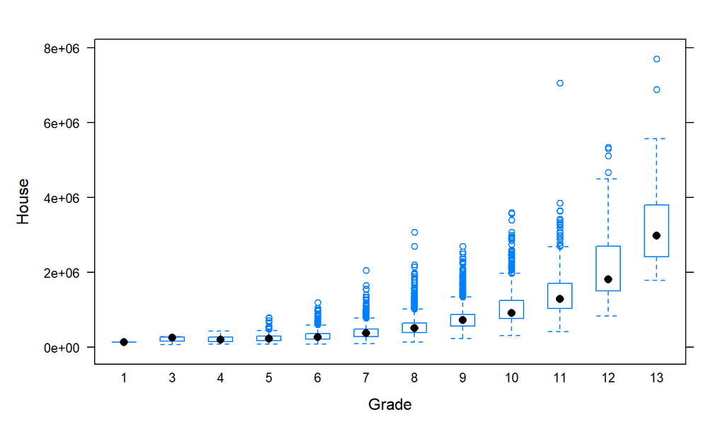

- A **increasing** relationship between grade and price

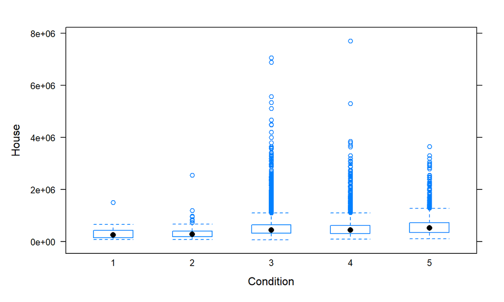

- **Little variation** in price with the change in the condition of the house.

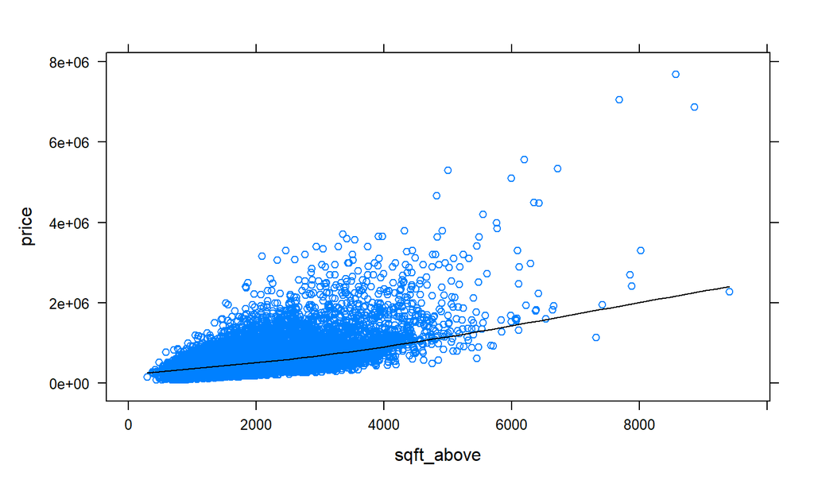

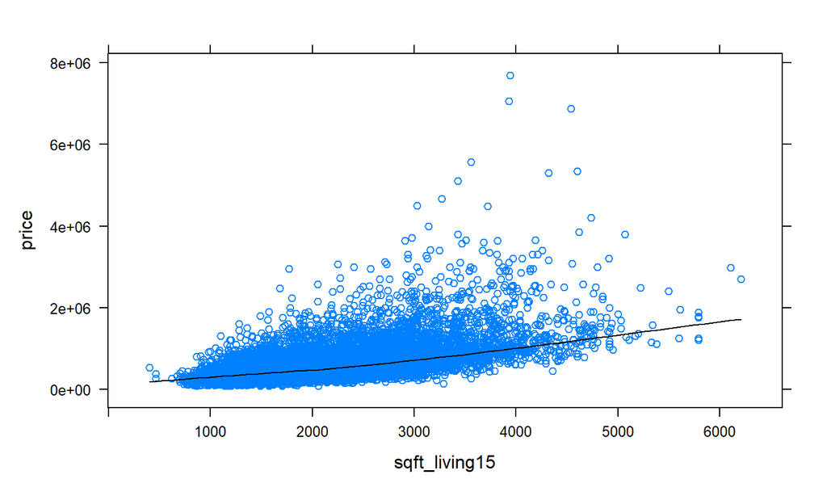

## Multiple Linear Regression

- Divide in **Train** and **Test** dataset
- Fit a multiple linear model

```
##
## Call:
## lm(formula = price ~ . - price, data = house_train)
##
## Residuals:
##      Min       1Q   Median       3Q      Max
## -1721459   -99310    -5947    84689  4043632
##
## Coefficients:
##                 Estimate Std. Error t value Pr(>|t|)
## (Intercept)    3.479e+06  2.555e+05  13.614  < 2e-16 ***
## date2015       2.834e+04  3.245e+03   8.735  < 2e-16 ***
## bedrooms      -2.070e+04  2.125e+03  -9.740  < 2e-16 ***
## bathrooms      3.547e+04  3.053e+03  11.617  < 2e-16 ***
## sqft_lot       1.047e-01  5.434e-02   1.926 0.054069 .
## floors         6.926e+02  3.804e+03   0.182 0.855512
## waterfront1    5.459e+05  2.191e+04  24.916  < 2e-16 ***
## view1          9.132e+04  1.248e+04   7.318 2.63e-13 ***
## view2          3.621e+04  7.556e+03   4.792 1.67e-06 ***
## view3          9.628e+04  1.042e+04   9.235  < 2e-16 ***
## view4          2.270e+05  1.587e+04  14.301  < 2e-16 ***
## condition2     4.700e+04  4.591e+04   1.024 0.305926
## condition3     8.144e+04  4.292e+04   1.898 0.057765 .
## condition4     1.082e+05  4.293e+04   2.520 0.011746 *
## condition5     1.511e+05  4.316e+04   3.501 0.000465 ***
## grade10        2.035e+05  2.038e+05   0.998 0.318135
## grade11        4.393e+05  2.042e+05   2.151 0.031464 *
## grade12        8.877e+05  2.054e+05   4.321 1.56e-05 ***
## grade13        2.390e+06  2.140e+05  11.172  < 2e-16 ***
## grade3        -7.347e+04  2.474e+05  -0.297 0.766530
## grade4        -1.833e+05  2.070e+05  -0.886 0.375873
## grade5        -2.148e+05  2.037e+05  -1.054 0.291686
## grade6        -1.953e+05  2.035e+05  -0.959 0.337419
## grade7        -1.449e+05  2.036e+05  -0.712 0.476620
## grade8        -7.071e+04  2.036e+05  -0.347 0.728380
## grade9         4.453e+04  2.037e+05   0.219 0.826935
## sqft_above     1.464e+02  4.170e+00  35.095  < 2e-16 ***
## sqft_basement  1.305e+02  4.787e+00  27.271  < 2e-16 ***
## yr_built      -1.706e+03  8.189e+01 -20.830  < 2e-16 ***
## zipcode9801   -9.025e+04  1.040e+04  -8.680  < 2e-16 ***
```

[output cut: 11 more lines]

```
## zipcode9814   -3.264e+04  1.013e+04  -3.221 0.001280 **
## zipcode9815   -5.455e+04  1.187e+04  -4.598 4.30e-06 ***
## zipcode9816   -1.394e+05  1.107e+04 -12.584  < 2e-16 ***
## zipcode9817   -9.393e+04  1.106e+04  -8.491  < 2e-16 ***
## zipcode9818   -1.536e+05  1.964e+04  -7.823 5.47e-15 ***
## zipcode9819   -2.250e+04  1.036e+04  -2.173 0.029828 *
## sqft_living15  5.571e+01  3.899e+00  14.289  < 2e-16 ***
## sqft_lot15    -2.967e-01  8.293e-02  -3.578 0.000347 ***
## renovated1     5.949e+04  8.205e+03   7.251 4.32e-13 ***
## ---
## Signif. codes:  0 '***' 0.001 '**' 0.01 '*' 0.05 '.' 0.1 ' ' 1
##
## Residual standard error: 198800 on 17240 degrees of freedom
## Multiple R-squared:  0.7108, Adjusted R-squared:   0.71
## F-statistic: 864.9 on 49 and 17240 DF,  p-value: < 2.2e-16
```

## hatvalues and rstudent

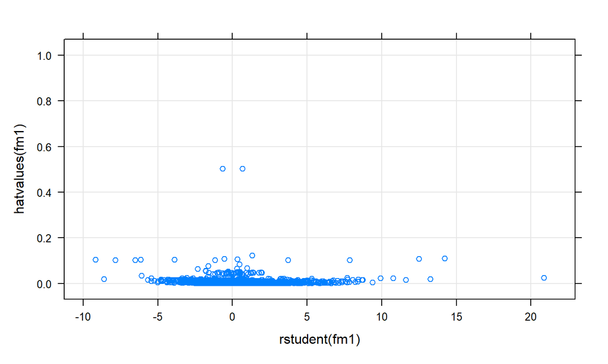

## hatvalues and rstudent

```r
id4=which(hatvalues(fm1) >0.4 | rstudent(fm1)>10)
```

- summary of new model

```
##
## Call:
## lm(formula = price ~ . - price, data = house_train4)
##
## Residuals:
##      Min       1Q   Median       3Q      Max
## -1567949   -98129    -6976    83122  2136429
##
## Coefficients:
##                 Estimate Std. Error t value Pr(>|t|)
## (Intercept)    3.700e+06  1.611e+05  22.971  < 2e-16 ***
## date2015       2.823e+04  3.124e+03   9.035  < 2e-16 ***
## bedrooms      -1.746e+04  2.048e+03  -8.528  < 2e-16 ***
## bathrooms      3.598e+04  2.943e+03  12.227  < 2e-16 ***
## sqft_lot       1.262e-01  5.231e-02   2.412 0.015859 *
## floors         3.703e+03  3.663e+03   1.011 0.312076
## waterfront1    5.069e+05  2.129e+04  23.811  < 2e-16 ***
## view1          9.390e+04  1.201e+04   7.817 5.73e-15 ***
## view2          3.503e+04  7.276e+03   4.815 1.48e-06 ***
## view3          9.463e+04  1.005e+04   9.419  < 2e-16 ***
## view4          2.268e+05  1.539e+04  14.740  < 2e-16 ***
## condition2     4.287e+04  4.420e+04   0.970 0.332089
## condition3     7.969e+04  4.131e+04   1.929 0.053761 .
## condition4     1.062e+05  4.132e+04   2.569 0.010193 *
## condition5     1.511e+05  4.154e+04   3.636 0.000277 ***
## grade11        2.345e+05  1.278e+04  18.346  < 2e-16 ***
## grade12        6.113e+05  2.450e+04  24.950  < 2e-16 ***
## grade13        1.604e+06  6.858e+04  23.392  < 2e-16 ***
## grade4        -4.172e+05  3.998e+04 -10.434  < 2e-16 ***
## grade5        -4.449e+05  1.769e+04 -25.142  < 2e-16 ***
## grade6        -4.229e+05  1.109e+04 -38.132  < 2e-16 ***
## grade7        -3.689e+05  9.160e+03 -40.268  < 2e-16 ***
## grade8        -2.900e+05  8.238e+03 -35.204  < 2e-16 ***
## grade9        -1.674e+05  7.943e+03 -21.071  < 2e-16 ***
## sqft_above     1.282e+02  4.047e+00  31.675  < 2e-16 ***
## sqft_basement  1.188e+02  4.624e+00  25.683  < 2e-16 ***
## yr_built      -1.702e+03  7.884e+01 -21.594  < 2e-16 ***
## zipcode9801   -8.698e+04  1.001e+04  -8.689  < 2e-16 ***
## zipcode9802   -1.147e+05  6.835e+03 -16.786  < 2e-16 ***
## zipcode9803   -4.645e+04  6.422e+03  -7.233 4.91e-13 ***
```

[output cut: 9 more lines]

```
## zipcode9814   -3.001e+04  9.757e+03  -3.076 0.002101 **
## zipcode9815   -5.151e+04  1.142e+04  -4.509 6.56e-06 ***
## zipcode9816   -1.342e+05  1.066e+04 -12.585  < 2e-16 ***
## zipcode9817   -8.815e+04  1.065e+04  -8.277  < 2e-16 ***
## zipcode9818   -1.507e+05  1.890e+04  -7.969 1.69e-15 ***
## zipcode9819   -1.861e+04  9.969e+03  -1.867 0.061923 .
## sqft_living15  6.131e+01  3.757e+00  16.319  < 2e-16 ***
## sqft_lot15    -2.762e-01  7.984e-02  -3.460 0.000541 ***
## renovated1     5.513e+04  7.903e+03   6.976 3.16e-12 ***
## ---
## Signif. codes:  0 '***' 0.001 '**' 0.01 '*' 0.05 '.' 0.1 ' ' 1
##
## Residual standard error: 191400 on 17233 degrees of freedom
## Multiple R-squared:  0.7079, Adjusted R-squared:  0.7071
## F-statistic: 888.6 on 47 and 17233 DF,  p-value: < 2.2e-16
```

## Bonferroni’s test

```r
n=nrow(house_train)
pi = 2 * pt(-abs(ti), df = fm1$df.residual - 1) # p-values
id1=which(1 - (1-pi)^n < 0.05)
```

- No. of points rejected

```
## [1] 98
```

-summary of new model

```
##
## Call:
## lm(formula = price ~ . - price, data = house_train1)
##
## Residuals:
##     Min      1Q  Median      3Q     Max
## -735362  -95021   -8071   80827 1069835
##
## Coefficients:
##                 Estimate Std. Error t value Pr(>|t|)
## (Intercept)    3.438e+06  2.147e+05  16.012  < 2e-16 ***
## date2015       2.606e+04  2.731e+03   9.541  < 2e-16 ***
## bedrooms      -1.496e+04  1.794e+03  -8.338  < 2e-16 ***
## bathrooms      2.994e+04  2.582e+03  11.598  < 2e-16 ***
## sqft_lot       1.827e-01  4.562e-02   4.005 6.22e-05 ***
## floors         1.147e+04  3.205e+03   3.579 0.000346 ***
## waterfront1    4.529e+05  1.960e+04  23.108  < 2e-16 ***
## view1          9.057e+04  1.053e+04   8.603  < 2e-16 ***
## view2          4.004e+04  6.384e+03   6.271 3.66e-10 ***
## view3          9.521e+04  8.856e+03  10.751  < 2e-16 ***
## view4          2.030e+05  1.382e+04  14.690  < 2e-16 ***
## condition2     3.331e+04  3.851e+04   0.865 0.387170
## condition3     7.442e+04  3.601e+04   2.067 0.038765 *
## condition4     9.813e+04  3.602e+04   2.724 0.006447 **
## condition5     1.434e+05  3.621e+04   3.962 7.48e-05 ***
## grade10        2.670e+05  1.710e+05   1.561 0.118456
## grade11        4.490e+05  1.713e+05   2.621 0.008786 **
## grade12        7.383e+05  1.726e+05   4.277 1.91e-05 ***
## grade13        2.291e+06  1.967e+05  11.645  < 2e-16 ***
## grade3        -4.981e+04  2.076e+05  -0.240 0.810362
## grade4        -1.599e+05  1.737e+05  -0.921 0.357165
## grade5        -1.840e+05  1.709e+05  -1.077 0.281563
## grade6        -1.569e+05  1.708e+05  -0.919 0.358186
## grade7        -9.484e+04  1.708e+05  -0.555 0.578679
## grade8        -1.171e+04  1.708e+05  -0.069 0.945367
## grade9         1.145e+05  1.709e+05   0.670 0.502912
## sqft_above     1.123e+02  3.590e+00  31.272  < 2e-16 ***
## sqft_basement  1.109e+02  4.090e+00  27.124  < 2e-16 ***
## yr_built      -1.697e+03  6.896e+01 -24.605  < 2e-16 ***
## zipcode9801   -7.932e+04  8.738e+03  -9.078  < 2e-16 ***
```

[output cut: 11 more lines]

```
## zipcode9814   -2.830e+04  8.532e+03  -3.317 0.000911 ***
## zipcode9815   -5.125e+04  9.978e+03  -5.137 2.83e-07 ***
## zipcode9816   -1.185e+05  9.329e+03 -12.702  < 2e-16 ***
## zipcode9817   -8.038e+04  9.305e+03  -8.639  < 2e-16 ***
## zipcode9818   -1.458e+05  1.648e+04  -8.843  < 2e-16 ***
## zipcode9819   -1.045e+04  8.715e+03  -1.199 0.230418
## sqft_living15  5.975e+01  3.316e+00  18.021  < 2e-16 ***
## sqft_lot15    -2.366e-01  6.961e-02  -3.398 0.000680 ***
## renovated1     4.741e+04  6.951e+03   6.821 9.36e-12 ***
## ---
## Signif. codes:  0 '***' 0.001 '**' 0.01 '*' 0.05 '.' 0.1 ' ' 1
##
## Residual standard error: 166800 on 17142 degrees of freedom
## Multiple R-squared:  0.7175, Adjusted R-squared:  0.7167
## F-statistic: 888.5 on 49 and 17142 DF,  p-value: < 2.2e-16
```

## Cook’s Distance

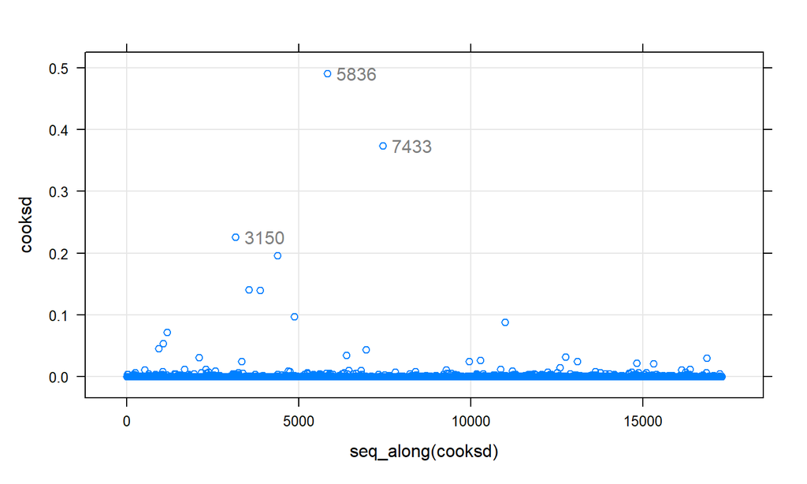

```r
cooksd=cooks.distance(fm1)
id2=which(cooksd>0.2)
xyplot(cooksd ~ seq_along(cooksd), grid = TRUE) +
    layer(panel.text(x[id2], y[id2], labels = rownames(house_train)[id2], pos = 4, col = "grey50"))
```

- No. of points rejected

```
## [1] 3
```

## Cook’s Distance

- Fit again a new model

```
##
## Call:
## lm(formula = price ~ . - price, data = house_train2)
##
## Residuals:
##      Min       1Q   Median       3Q      Max
## -1685332   -98642    -6699    83604  2610730
##
## Coefficients:
##                 Estimate Std. Error t value Pr(>|t|)
## (Intercept)    3.445e+06  2.493e+05  13.816  < 2e-16 ***
## date2015       2.884e+04  3.166e+03   9.107  < 2e-16 ***
## bedrooms      -1.802e+04  2.076e+03  -8.681  < 2e-16 ***
## bathrooms      3.558e+04  2.982e+03  11.931  < 2e-16 ***
## sqft_lot       1.164e-01  5.303e-02   2.195 0.028154 *
## floors         2.924e+03  3.713e+03   0.788 0.430963
## waterfront1    5.087e+05  2.151e+04  23.647  < 2e-16 ***
## view1          9.295e+04  1.218e+04   7.634 2.39e-14 ***
## view2          3.393e+04  7.375e+03   4.600 4.26e-06 ***
## view3          9.303e+04  1.018e+04   9.136  < 2e-16 ***
## view4          2.390e+05  1.556e+04  15.360  < 2e-16 ***
## condition2     4.509e+04  4.479e+04   1.007 0.314180
## condition3     8.080e+04  4.188e+04   1.929 0.053716 .
## condition4     1.075e+05  4.189e+04   2.566 0.010308 *
## condition5     1.516e+05  4.211e+04   3.601 0.000318 ***
## grade10        2.276e+05  1.989e+05   1.144 0.252559
## grade11        4.593e+05  1.992e+05   2.305 0.021165 *
## grade12        9.322e+05  2.004e+05   4.651 3.33e-06 ***
## grade13        1.822e+06  2.108e+05   8.643  < 2e-16 ***
## grade3        -6.999e+04  2.414e+05  -0.290 0.771913
## grade4        -1.814e+05  2.020e+05  -0.898 0.369112
## grade5        -2.100e+05  1.987e+05  -1.057 0.290563
## grade6        -1.888e+05  1.986e+05  -0.951 0.341820
## grade7        -1.358e+05  1.986e+05  -0.684 0.494152
## grade8        -5.824e+04  1.987e+05  -0.293 0.769408
## grade9         6.239e+04  1.988e+05   0.314 0.753598
## sqft_above     1.325e+02  4.097e+00  32.341  < 2e-16 ***
## sqft_basement  1.213e+02  4.686e+00  25.880  < 2e-16 ***
## yr_built      -1.692e+03  7.991e+01 -21.178  < 2e-16 ***
## zipcode9801   -8.811e+04  1.015e+04  -8.684  < 2e-16 ***
```

[output cut: 11 more lines]

```
## zipcode9814   -3.094e+04  9.890e+03  -3.129 0.001759 **
## zipcode9815   -5.286e+04  1.158e+04  -4.565 5.02e-06 ***
## zipcode9816   -1.361e+05  1.081e+04 -12.592  < 2e-16 ***
## zipcode9817   -9.043e+04  1.080e+04  -8.377  < 2e-16 ***
## zipcode9818   -1.518e+05  1.916e+04  -7.923 2.46e-15 ***
## zipcode9819   -1.918e+04  1.011e+04  -1.898 0.057720 .
## sqft_living15  6.033e+01  3.808e+00  15.842  < 2e-16 ***
## sqft_lot15    -2.813e-01  8.093e-02  -3.476 0.000511 ***
## renovated1     5.407e+04  8.011e+03   6.750 1.53e-11 ***
## ---
## Signif. codes:  0 '***' 0.001 '**' 0.01 '*' 0.05 '.' 0.1 ' ' 1
##
## Residual standard error: 194000 on 17237 degrees of freedom
## Multiple R-squared:  0.7081, Adjusted R-squared:  0.7073
## F-statistic: 853.4 on 49 and 17237 DF,  p-value: < 2.2e-16
```

## Covratio

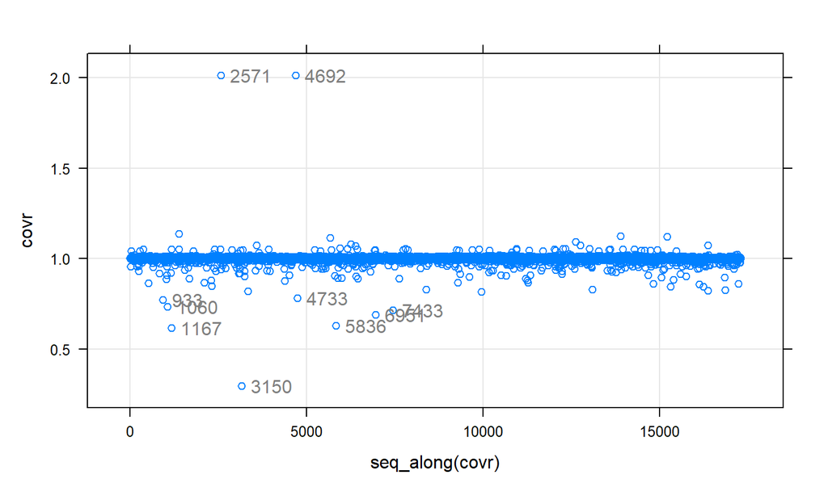

```r
covr = covratio(fm1)
id3 =which(abs(covr-1) > 0.2)
xyplot(covr ~ seq_along(covr), grid = TRUE) +
    layer(panel.text(x[id3], y[id3], labels = rownames(house_train)[id3], pos = 4, col = "grey50"))
```

- No. pof points rejected

```
## [1] 10
```

## Covratio

- summary

```
##
## Call:
## lm(formula = price ~ . - price, data = house_train3)
##
## Residuals:
##      Min       1Q   Median       3Q      Max
## -1534232   -98104    -7053    82729  2144118
##
## Coefficients:
##                 Estimate Std. Error t value Pr(>|t|)
## (Intercept)    3.461e+06  2.444e+05  14.160  < 2e-16 ***
## date2015       2.858e+04  3.104e+03   9.206  < 2e-16 ***
## bedrooms      -1.719e+04  2.035e+03  -8.448  < 2e-16 ***
## bathrooms      3.573e+04  2.924e+03  12.217  < 2e-16 ***
## sqft_lot       1.292e-01  5.198e-02   2.486 0.012923 *
## floors         4.481e+03  3.640e+03   1.231 0.218281
## waterfront1    4.916e+05  2.120e+04  23.194  < 2e-16 ***
## view1          9.431e+04  1.193e+04   7.902 2.90e-15 ***
## view2          3.570e+04  7.229e+03   4.938 7.96e-07 ***
## view3          9.595e+04  9.982e+03   9.613  < 2e-16 ***
## view4          2.267e+05  1.529e+04  14.833  < 2e-16 ***
## condition2     4.208e+04  4.391e+04   0.958 0.337978
## condition3     7.918e+04  4.105e+04   1.929 0.053749 .
## condition4     1.059e+05  4.106e+04   2.579 0.009903 **
## condition5     1.510e+05  4.128e+04   3.659 0.000254 ***
## grade10        2.426e+05  1.950e+05   1.244 0.213454
## grade11        4.726e+05  1.953e+05   2.420 0.015536 *
## grade12        8.268e+05  1.965e+05   4.208 2.59e-05 ***
## grade13        1.852e+06  2.066e+05   8.965  < 2e-16 ***
## grade4        -1.785e+05  1.980e+05  -0.902 0.367305
## grade5        -2.053e+05  1.948e+05  -1.054 0.291886
## grade6        -1.831e+05  1.947e+05  -0.940 0.347031
## grade7        -1.283e+05  1.947e+05  -0.659 0.509735
## grade8        -4.919e+04  1.947e+05  -0.253 0.800559
## grade9         7.416e+04  1.948e+05   0.381 0.703459
## sqft_above     1.257e+02  4.025e+00  31.219  < 2e-16 ***
## sqft_basement  1.173e+02  4.597e+00  25.524  < 2e-16 ***
## yr_built      -1.703e+03  7.833e+01 -21.738  < 2e-16 ***
## zipcode9801   -8.748e+04  9.946e+03  -8.795  < 2e-16 ***
## zipcode9802   -1.153e+05  6.791e+03 -16.973  < 2e-16 ***
```

[output cut: 10 more lines]

```
## zipcode9814   -3.055e+04  9.694e+03  -3.152 0.001624 **
## zipcode9815   -5.179e+04  1.135e+04  -4.563 5.07e-06 ***
## zipcode9816   -1.341e+05  1.059e+04 -12.656  < 2e-16 ***
## zipcode9817   -8.843e+04  1.058e+04  -8.357  < 2e-16 ***
## zipcode9818   -1.511e+05  1.878e+04  -8.044 9.22e-16 ***
## zipcode9819   -1.919e+04  9.905e+03  -1.937 0.052756 .
## sqft_living15  6.284e+01  3.734e+00  16.829  < 2e-16 ***
## sqft_lot15    -2.732e-01  7.932e-02  -3.444 0.000575 ***
## renovated1     5.623e+04  7.852e+03   7.161 8.32e-13 ***
## ---
## Signif. codes:  0 '***' 0.001 '**' 0.01 '*' 0.05 '.' 0.1 ' ' 1
##
## Residual standard error: 190100 on 17231 degrees of freedom
## Multiple R-squared:  0.7078, Adjusted R-squared:  0.7069
## F-statistic: 869.4 on 48 and 17231 DF,  p-value: < 2.2e-16
```

## Non-Normality

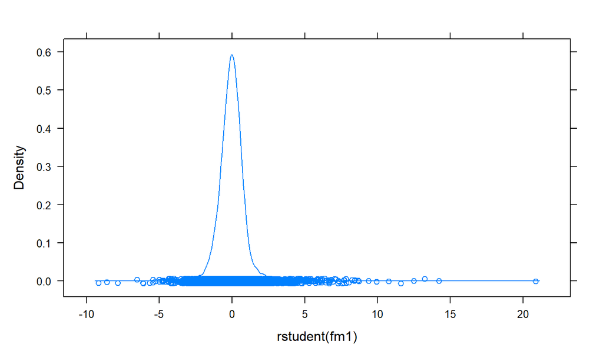

```r
densityplot(~rstudent(fm1))
```

## Non-Normality

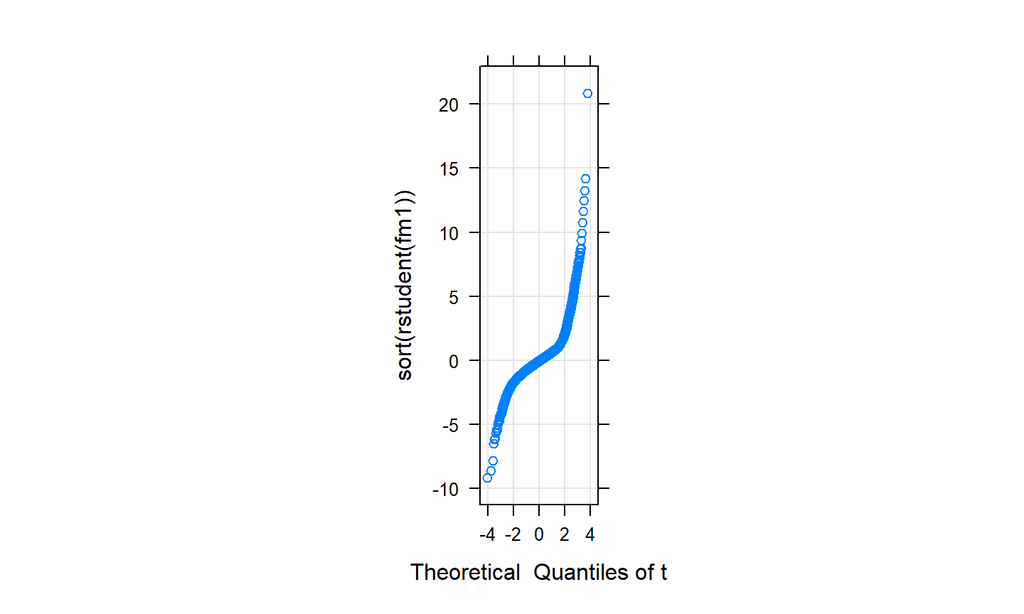

```r
xyplot(sort(rstudent(fm1)) ~ qt(ppoints(nrow(house_train)), df = fm1$df.residual - 1), grid = TRUE, aspect = "iso",xlab="Theoretical  Quantiles of t")
```

## Non-Normality

```r
e_rstudent=rstudent(fm1)
ks.test(e_rstudent,pnorm)
```

```
##
##  One-sample Kolmogorov-Smirnov test
##
## data:  e_rstudent
## D = 0.099378, p-value < 2.2e-16
## alternative hypothesis: two-sided
```

## Non-Normality

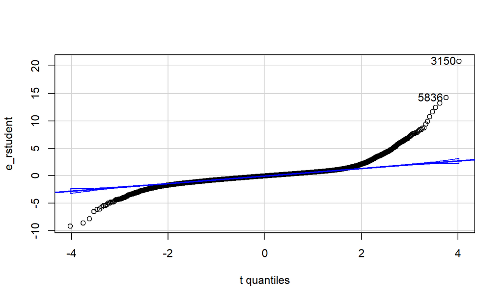

```
## [1] 3150 5836
```

```r
qqPlot(e_rstudent,distribution = "t",df=fm1$df.residual - 1)
```

## Remeady of Non-normality

- **Boxcox** Transformation

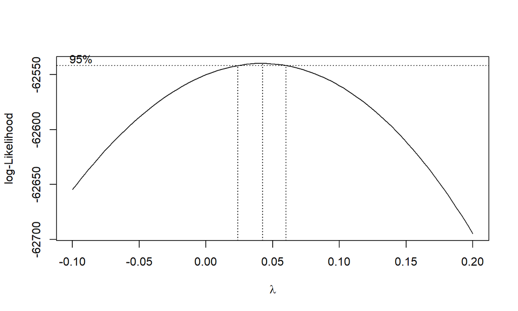

```r
#par(mar = c(5, 8, 1, 2))
boxcox(fm1, lambda = seq(-0.1, 0.2, 0.01), plotit = TRUE,grid=TRUE)
```

## Remeady of Non-normality

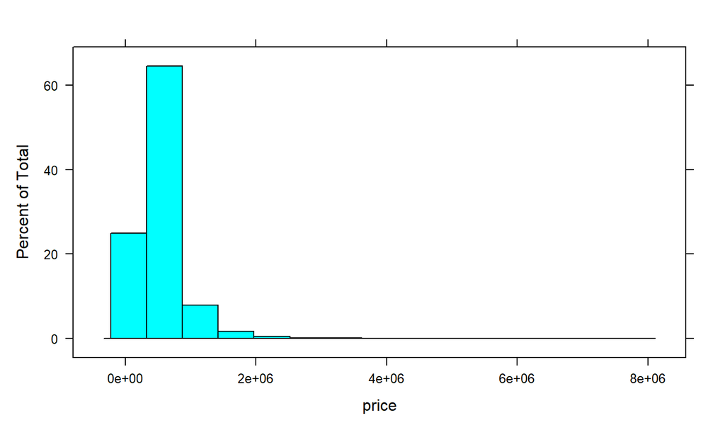

```r
histogram(~price,data=house_train)
```

## Remeady of Non-normality

- From both the plot taking log transformation is justified

```r
house_train$price=log(house_train$price)
```

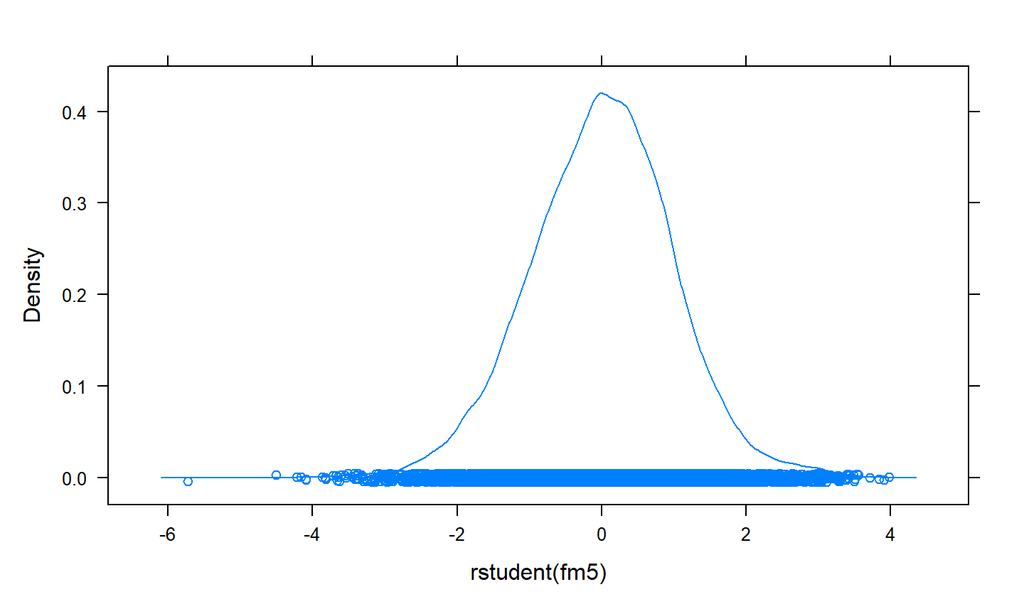

```r
fm5=lm(price~.-price,data=house_train)
densityplot(~rstudent(fm5))
```

## Remeady of Non-normality

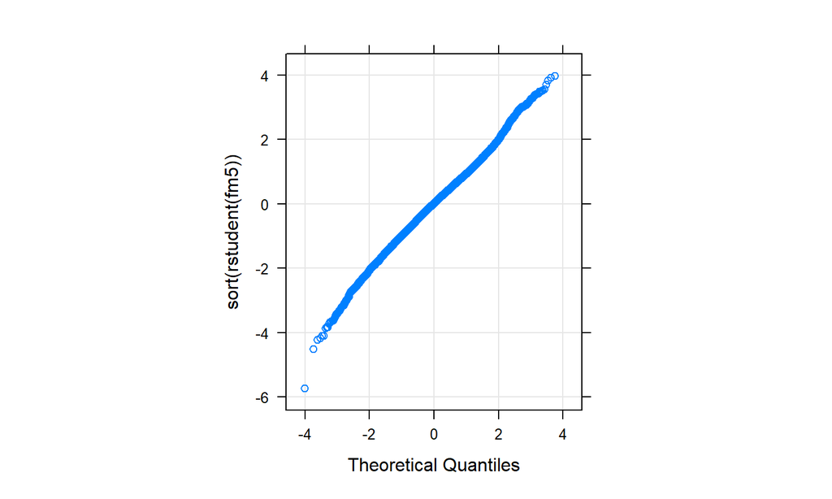

```r
xyplot(sort(rstudent(fm5)) ~ qt(ppoints(nrow(house_train)), df = fm5$df.residual - 1), grid = TRUE, aspect = "iso",xlab="Theoretical Quantiles")
```

## Remeady of Non-normality

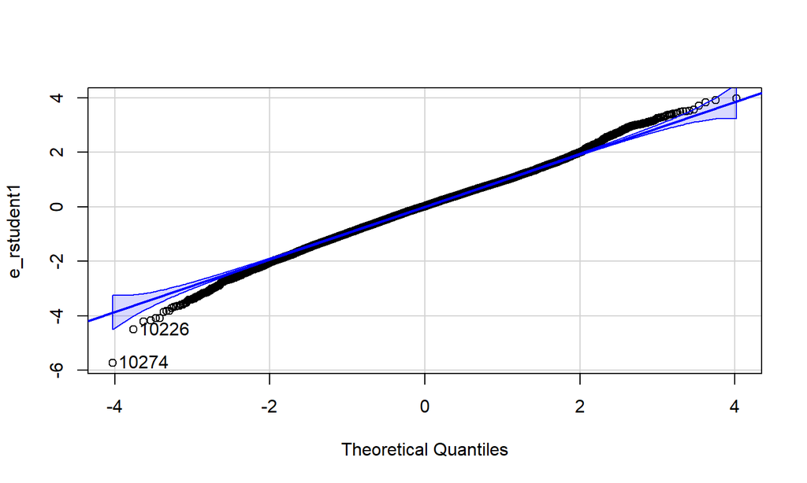

```
## [1] 10274 10226
```

```r
qqPlot(e_rstudent1,distribution = "t",df=fm5$df.residual - 1,xlab="Theoretical Quantiles")
```

## Non-Constant Variance

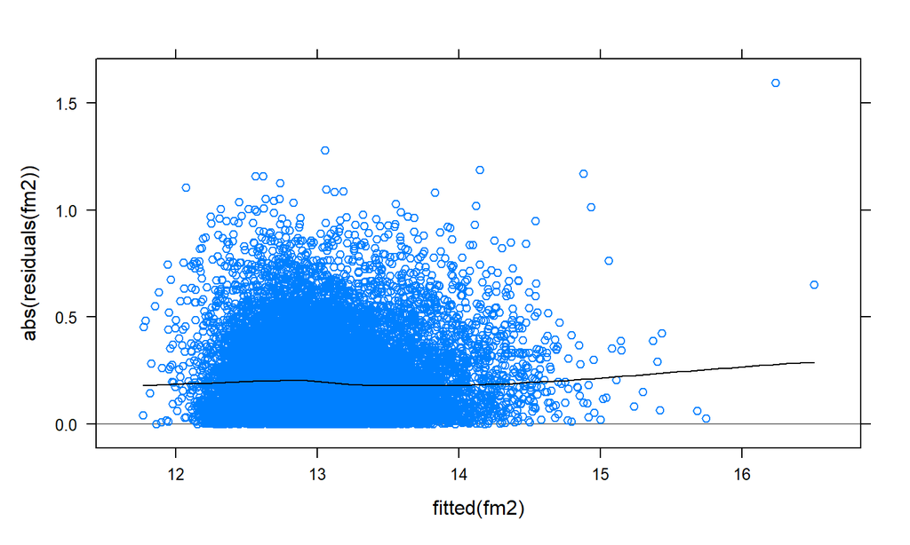

```r
xyplot(abs(residuals(fm5))~fitted(fm5),type=c("p","smooth"),col.line="black",abline = list(h = 0, col = "grey50"),xlab="fitted(fm2)",ylab="abs(residuals(fm2))")
```

```r
ncvTest(fm5)
```

```
## Non-constant Variance Score Test
## Variance formula: ~ fitted.values
## Chisquare = 0.502672, Df = 1, p = 0.47833
```

## Final Multiple Linear Model

```
##
## Call:
## lm(formula = price ~ . - price, data = house_train)
##
## Residuals:
##      Min       1Q   Median       3Q      Max
## -1.59497 -0.18371  0.00573  0.18448  1.12734
##
## Coefficients:
##                 Estimate Std. Error t value Pr(>|t|)
## (Intercept)    1.742e+01  3.647e-01  47.759  < 2e-16 ***
## date2015       4.725e-02  4.631e-03  10.203  < 2e-16 ***
## bedrooms      -1.698e-02  3.032e-03  -5.601 2.17e-08 ***
## bathrooms      4.859e-02  4.356e-03  11.155  < 2e-16 ***
## sqft_lot       4.162e-07  7.755e-08   5.367 8.11e-08 ***
## floors         2.595e-02  5.428e-03   4.781 1.76e-06 ***
## waterfront1    4.024e-01  3.126e-02  12.872  < 2e-16 ***
## view1          1.372e-01  1.781e-02   7.706 1.37e-14 ***
## view2          6.568e-02  1.078e-02   6.091 1.14e-09 ***
## view3          9.494e-02  1.488e-02   6.382 1.79e-10 ***
## view4          1.845e-01  2.265e-02   8.145 4.06e-16 ***
## condition2    -1.939e-02  6.551e-02  -0.296 0.767293
## condition3     1.689e-01  6.125e-02   2.757 0.005836 **
## condition4     2.159e-01  6.126e-02   3.525 0.000425 ***
## condition5     2.864e-01  6.159e-02   4.650 3.35e-06 ***
## grade10        8.105e-01  2.909e-01   2.786 0.005339 **
## grade11        8.738e-01  2.914e-01   2.999 0.002713 **
## grade12        9.665e-01  2.931e-01   3.297 0.000978 ***
## grade13        1.150e+00  3.053e-01   3.765 0.000167 ***
## grade3         4.105e-01  3.531e-01   1.163 0.244971
## grade4        -1.025e-01  2.954e-01  -0.347 0.728649
## grade5        -7.909e-02  2.906e-01  -0.272 0.785531
## grade6         1.002e-01  2.905e-01   0.345 0.730242
## grade7         3.194e-01  2.905e-01   1.100 0.271488
## grade8         5.152e-01  2.905e-01   1.773 0.076224 .
## grade9         6.904e-01  2.907e-01   2.375 0.017547 *
## sqft_above     1.664e-04  5.951e-06  27.958  < 2e-16 ***
## sqft_basement  1.590e-04  6.831e-06  23.277  < 2e-16 ***
## yr_built      -2.925e-03  1.169e-04 -25.030  < 2e-16 ***
## zipcode9801   -4.744e-02  1.484e-02  -3.197 0.001390 **
```

[output cut: 11 more lines]

```
## zipcode9814    7.409e-03  1.446e-02   0.512 0.608435
## zipcode9815    3.683e-04  1.693e-02   0.022 0.982644
## zipcode9816   -2.102e-01  1.580e-02 -13.299  < 2e-16 ***
## zipcode9817   -8.510e-02  1.579e-02  -5.391 7.11e-08 ***
## zipcode9818   -2.958e-01  2.802e-02 -10.556  < 2e-16 ***
## zipcode9819    8.061e-03  1.478e-02   0.546 0.585397
## sqft_living15  1.527e-04  5.564e-06  27.454  < 2e-16 ***
## sqft_lot15    -1.705e-07  1.183e-07  -1.440 0.149761
## renovated1     6.663e-02  1.171e-02   5.691 1.28e-08 ***
## ---
## Signif. codes:  0 '***' 0.001 '**' 0.01 '*' 0.05 '.' 0.1 ' ' 1
##
## Residual standard error: 0.2837 on 17240 degrees of freedom
## Multiple R-squared:  0.7094, Adjusted R-squared:  0.7086
## F-statistic: 858.9 on 49 and 17240 DF,  p-value: < 2.2e-16
```

## New Mutiple Linear Model

- Predictive R Square

```
## [1] 0.7093931
```

- Actual vs Predicted in Test data set

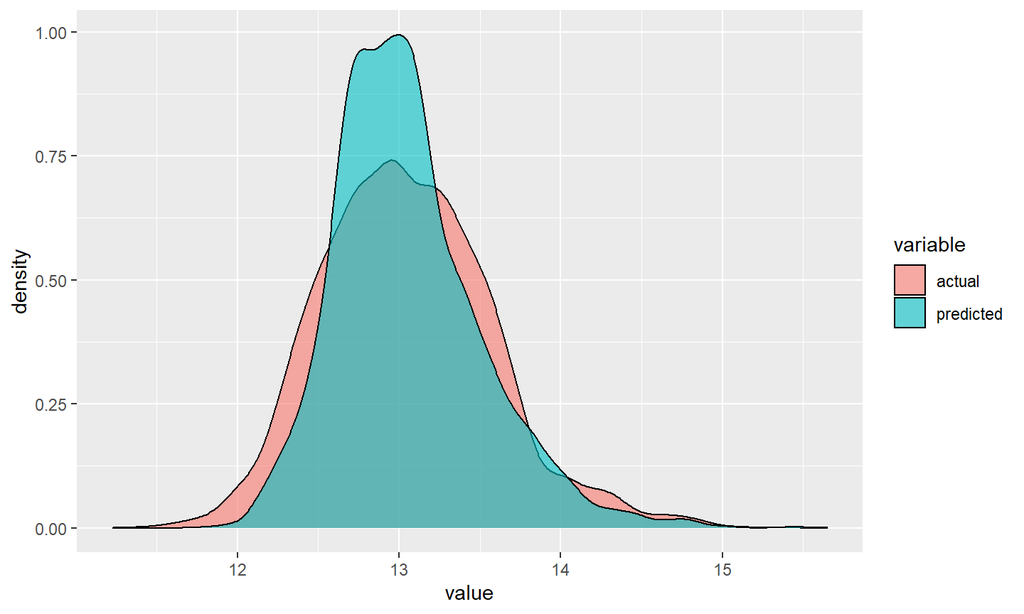

## RLM

-Take Loss function **Bisqaure** and **Huber**

- Actual vs Predicted in Test data set using rlm taking loss function Bisquare

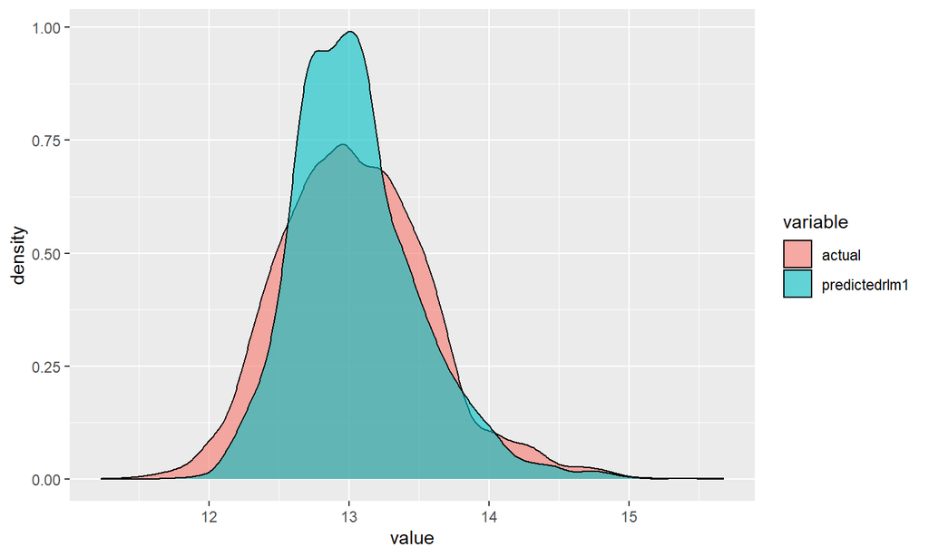

## RLM

- Actual vs Predicted in Test data set using rlm taking loss function Huber

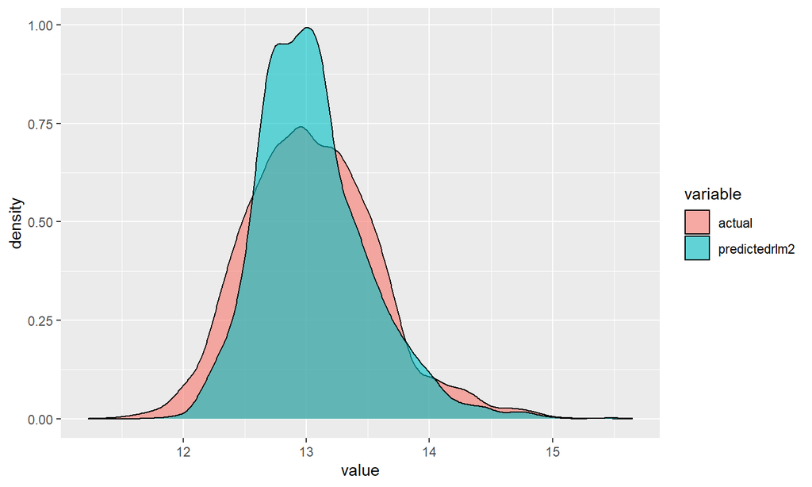

## LASSO

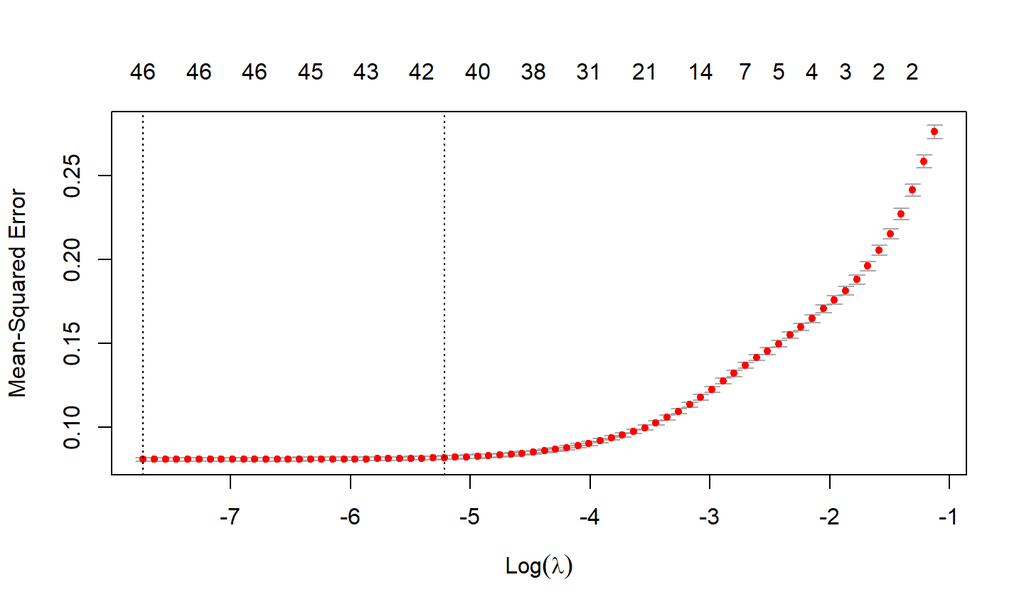

```r
plot(cv.lasso)
```

## LASSO

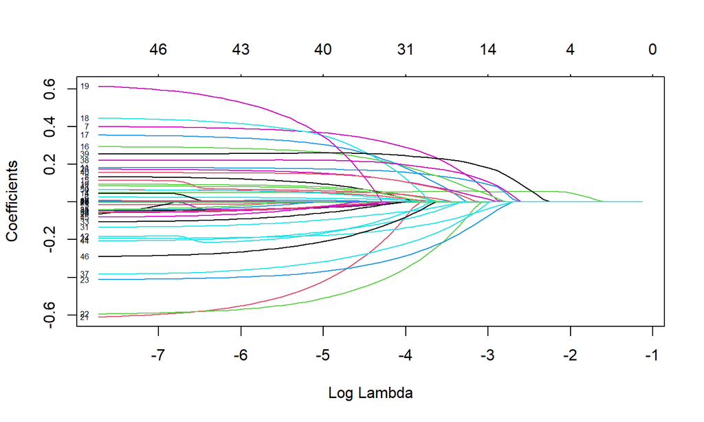

```r
plot(fm.lasso, xvar = "lambda", label = TRUE)
```

## LASSO

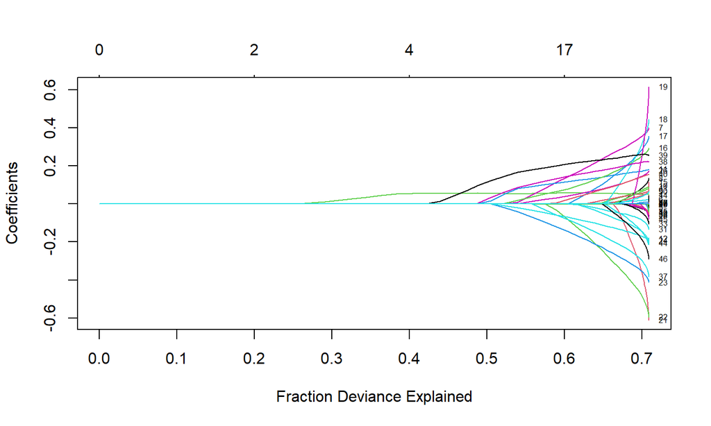

[output not shown]

```r
plot(fm.lasso, xvar = "dev", label = TRUE)
```

## LASSO

- All non-zero predictors

```
## 51 x 1 sparse Matrix of class "dgCMatrix"
##                   s1
## (Intercept)   17.834
## date2014      -0.033
## date2015       .
## bedrooms      -0.004
## bathrooms      0.049
## sqft_lot       0.000
## floors         0.021
## waterfront1    0.375
## view1          0.105
## view2          0.053
## view3          0.083
## view4          0.177
## condition2    -0.179
## condition3    -0.031
## condition4     .
## condition5     0.061
## grade10        0.271
## grade11        0.318
## grade12        0.374
## grade13        0.406
## grade3         .
## grade4        -0.461
## grade5        -0.530
## grade6        -0.379
## grade7        -0.181
## grade8         .
## grade9         0.158
## sqft_above     0.000
## sqft_basement  0.000
## yr_built      -0.003
## zipcode9801   -0.004
## zipcode9802   -0.102
## zipcode9803   -0.031
## zipcode9804   -0.067
## zipcode9805   -0.027
## zipcode9806    .
## zipcode9807    0.009
## zipcode9809   -0.329
## zipcode9810    0.222
## zipcode9811    0.259
## zipcode9812    0.150
## zipcode9813    0.075
## zipcode9814    .
## zipcode9815    .
## zipcode9816   -0.168
## zipcode9817   -0.035
## zipcode9818   -0.226
## zipcode9819    .
## sqft_living15  0.000
## sqft_lot15     .
## renovated1     0.050
```

## LASSO

- Fit a new multiple linear model with these predictors

```
##
## Call:
## lm(formula = price ~ . - price, data = df2)
##
## Residuals:
##      Min       1Q   Median       3Q      Max
## -1.36541 -0.21507  0.00025  0.20600  1.60732
##
## Coefficients:
##               Estimate Std. Error t value Pr(>|t|)
## (Intercept) 19.9316434  0.2572560  77.478  < 2e-16 ***
## date2014    -0.0410366  0.0053314  -7.697 1.47e-14 ***
## bedrooms     0.0389166  0.0031555  12.333  < 2e-16 ***
## bathrooms    0.1535594  0.0045363  33.851  < 2e-16 ***
## floors       0.0517362  0.0054775   9.445  < 2e-16 ***
## waterfront1  0.3498132  0.0359695   9.725  < 2e-16 ***
## view1        0.2195880  0.0203654  10.782  < 2e-16 ***
## view2        0.1559821  0.0122553  12.728  < 2e-16 ***
## view3        0.2427080  0.0167846  14.460  < 2e-16 ***
## view4        0.3852242  0.0257834  14.941  < 2e-16 ***
## condition2  -0.2298404  0.0284968  -8.065 7.77e-16 ***
## condition3  -0.0316161  0.0063304  -4.994 5.96e-07 ***
## condition5   0.0631404  0.0102051   6.187 6.26e-10 ***
## grade11      0.6318923  0.0195454  32.330  < 2e-16 ***
## grade12      0.8803888  0.0393726  22.360  < 2e-16 ***
## grade13      1.2634331  0.1041886  12.126  < 2e-16 ***
## grade4      -0.8170755  0.0662957 -12.325  < 2e-16 ***
## grade5      -0.8168745  0.0253136 -32.270  < 2e-16 ***
## grade6      -0.6067780  0.0108596 -55.875  < 2e-16 ***
## grade7      -0.3529115  0.0065238 -54.096  < 2e-16 ***
## grade9       0.2211946  0.0084488  26.180  < 2e-16 ***
## yr_built    -0.0036638  0.0001317 -27.825  < 2e-16 ***
## zipcode9801 -0.0022010  0.0159152  -0.138  0.89001
## zipcode9802 -0.1290837  0.0103002 -12.532  < 2e-16 ***
## zipcode9803 -0.0494879  0.0095527  -5.180 2.24e-07 ***
## zipcode9804 -0.0714873  0.0126914  -5.633 1.80e-08 ***
## zipcode9805 -0.0231485  0.0093152  -2.485  0.01296 *
## zipcode9807  0.1257964  0.0115804  10.863  < 2e-16 ***
## zipcode9809 -0.3680959  0.0204854 -17.969  < 2e-16 ***
## zipcode9810  0.1054192  0.0107558   9.801  < 2e-16 ***
## zipcode9811  0.1808079  0.0098372  18.380  < 2e-16 ***
## zipcode9812  0.0565631  0.0127977   4.420 9.94e-06 ***
## zipcode9813  0.0136070  0.0143834   0.946  0.34415
## zipcode9816 -0.2376508  0.0171857 -13.828  < 2e-16 ***
## zipcode9817 -0.1123213  0.0172116  -6.526 6.95e-11 ***
## zipcode9818 -0.3300963  0.0317432 -10.399  < 2e-16 ***
## renovated1   0.0416881  0.0134531   3.099  0.00195 **
## ---
## Signif. codes:  0 '***' 0.001 '**' 0.01 '*' 0.05 '.' 0.1 ' ' 1
##
## Residual standard error: 0.3268 on 17253 degrees of freedom
## Multiple R-squared:  0.6141, Adjusted R-squared:  0.6133
## F-statistic: 762.8 on 36 and 17253 DF,  p-value: < 2.2e-16
```

## LASSO

- Cheaking the assumption of linear model

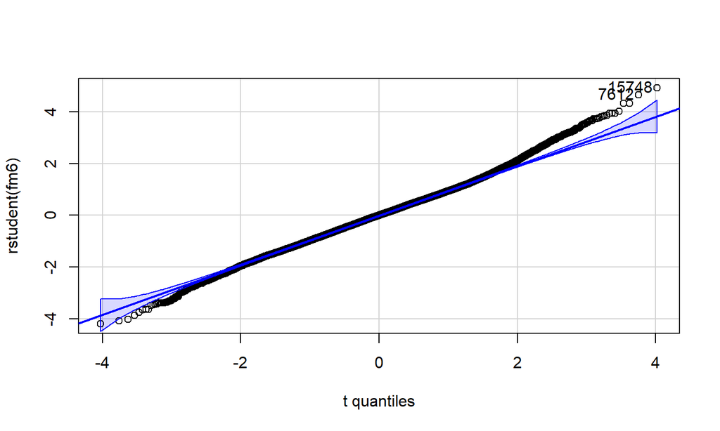

```
## [1] 15748  7612
```

## LASSO

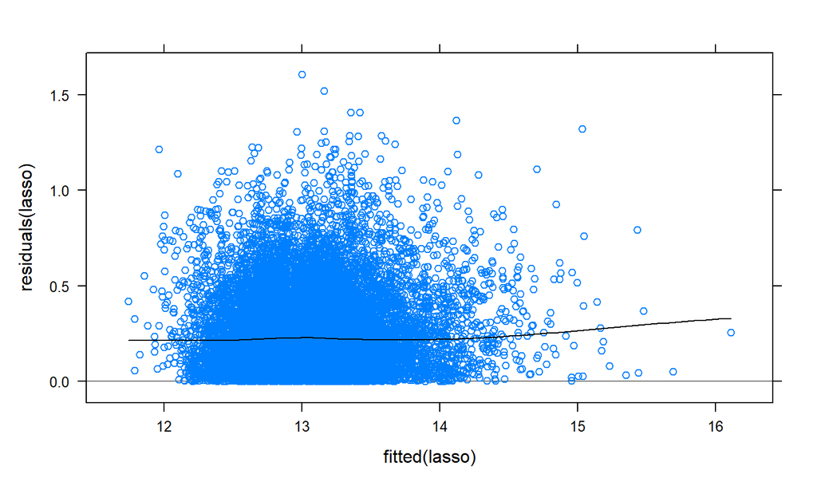

## LASSO

- Actual vs Fitted of the test data using this model

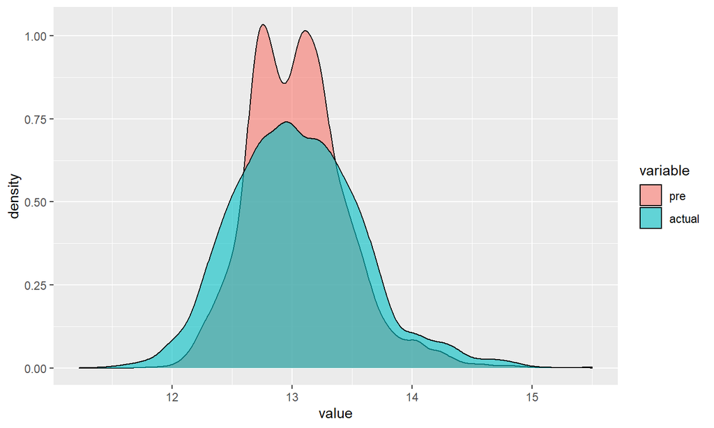

- Predictive R square of lasso

```
## [1] 0.6141457
```

## Comparison Between all the linear model

- Correlation Between Actual and Predicted for test data set
- Mutiple linear Regression

```
## [1] 0.8462391
```

- rlm with bisquare loss function

```
## [1] 0.8457159
```

- rlm with Huber loss function

```
## [1] 0.8458957
```

- Multiple linear Regression from LASSO

```
## [1] 0.7927181
```

## Comparison Between all the linear model

- Comparing all of this correlation we get Multiple linear Regression , both rlm with bisquare and huber are similar for prediction purpose and better than LASSO.
- Again by comapring Predictive R square between multiple linear model and lasso , we get multiple linear model is better than lasso.

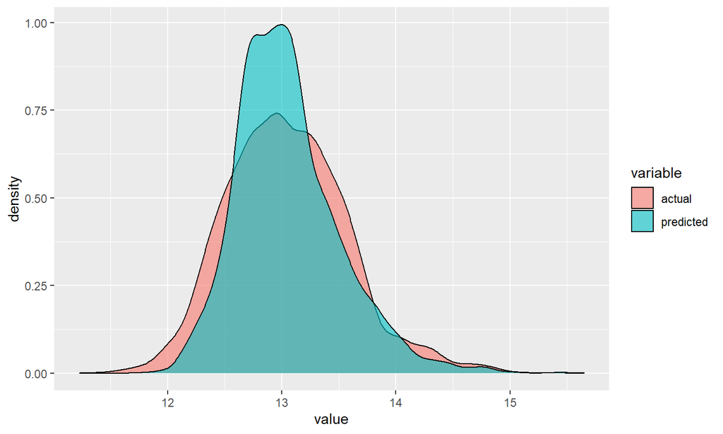

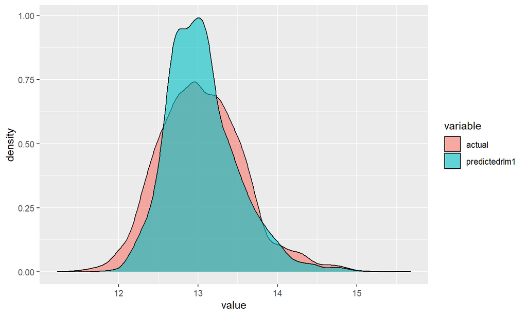

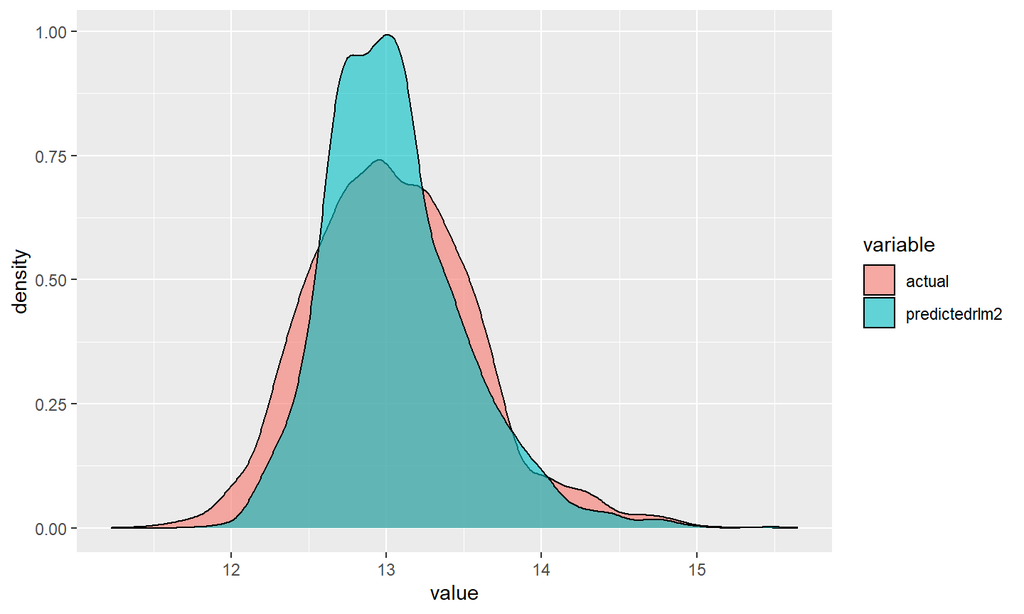

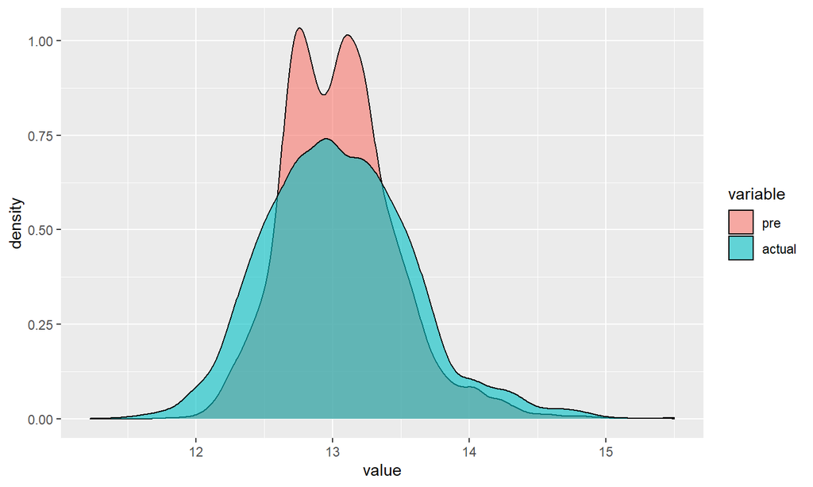